# Data Analysis with R Workshop

2018-12-21

[figure not shown]

## Data Sources

- Sensor
- Text
- Image
- Videos
- Survey

## Data Types

Basic structured data types 1.Numeric 2. Categorical

- continuous windspeed
- Discrete Count of the occurence of the event
- Categorical Type of Tv Screen
- Binary Yes/No 0/1
- Ordinal 1,2,3,4,5

## Loading Data

```r
mpg <- read.csv("mpg.csv")
```

### Fuel economy data from 1999 and 2008 for 38 popular models of car

#### Description

This dataset contains a subset of the fuel economy data that the EPA makes available on http://fueleconomy.gov. It contains only models which had a new release every year between 1999 and 2008 - this was used as a proxy for the popularity of the car.

## Data Exploration

```r
str(mpg)
```

```
## 'data.frame':    234 obs. of  11 variables:
##  $ manufacturer: Factor w/ 15 levels "audi","chevrolet",..: 1 1 1 1 1 1 1 1 1 1 ...
##  $ model       : Factor w/ 38 levels "4runner 4wd",..: 2 2 2 2 2 2 2 3 3 3 ...
##  $ displ       : num  1.8 1.8 2 2 2.8 2.8 3.1 1.8 1.8 2 ...
##  $ year        : int  1999 1999 2008 2008 1999 1999 2008 1999 1999 2008 ...
##  $ cyl         : int  4 4 4 4 6 6 6 4 4 4 ...
##  $ trans       : Factor w/ 10 levels "auto(av)","auto(l3)",..: 4 9 10 1 4 9 1 9 4 10 ...
##  $ drv         : Factor w/ 3 levels "4","f","r": 2 2 2 2 2 2 2 1 1 1 ...
##  $ cty         : int  18 21 20 21 16 18 18 18 16 20 ...
##  $ hwy         : int  29 29 31 30 26 26 27 26 25 28 ...
##  $ fl          : Factor w/ 5 levels "c","d","e","p",..: 4 4 4 4 4 4 4 4 4 4 ...
##  $ class       : Factor w/ 7 levels "2seater","compact",..: 2 2 2 2 2 2 2 2 2 2 ...
```

str() function shows the structure of the dataframe.

### Chop the Head and Tail

```r
head(mpg)
```

| manufacturer | model | displ | year | cyl | trans | drv | cty | hwy | fl | class |
| --- | --- | --- | --- | --- | --- | --- | --- | --- | --- | --- |
| audi | a4 | 1.8 | 1999 | 4 | auto(l5) | f | 18 | 29 | p | compact |
| audi | a4 | 1.8 | 1999 | 4 | manual(m5) | f | 21 | 29 | p | compact |
| audi | a4 | 2.0 | 2008 | 4 | manual(m6) | f | 20 | 31 | p | compact |
| audi | a4 | 2.0 | 2008 | 4 | auto(av) | f | 21 | 30 | p | compact |
| audi | a4 | 2.8 | 1999 | 6 | auto(l5) | f | 16 | 26 | p | compact |
| audi | a4 | 2.8 | 1999 | 6 | manual(m5) | f | 18 | 26 | p | compact |

head() gives the first 6 rows of the dataframe by default.

```r
tail(mpg)
```

[output not shown]

tail() gives the last 6 rows of the dataframe by default.

## Central Tendency

Basic Step in exploring data

#### Mean

```r
mean(mpg$cyl) ## $ select the column of dataframe
```

```
## [1] 5.888889
```

#### Median

```r
median(mpg$cyl)
```

```
## [1] 6
```

## Estimates of Variability

#### Variance

```r
var(mpg$displ)
```

```
## [1] 1.669158
```

#### Standard Deviation(SD)

```r
sd(mpg$cyl)
```

```
## [1] 1.611534
```

#### Range

```r
range(mpg$displ)
```

```
## [1] 1.6 7.0
```

#### Percentile

```r
quantile(mpg$displ)
```

```
##   0%  25%  50%  75% 100%
##  1.6  2.4  3.3  4.6  7.0
```

## Summary

```r
summary(mpg)
```

```
##      manufacturer                 model         displ            year
##  dodge     :37    caravan 2wd        : 11   Min.   :1.600   Min.   :1999
##  toyota    :34    ram 1500 pickup 4wd: 10   1st Qu.:2.400   1st Qu.:1999
##  volkswagen:27    civic              :  9   Median :3.300   Median :2004
##  ford      :25    dakota pickup 4wd  :  9   Mean   :3.472   Mean   :2004
##  chevrolet :19    jetta              :  9   3rd Qu.:4.600   3rd Qu.:2008
##  audi      :18    mustang            :  9   Max.   :7.000   Max.   :2008
##  (Other)   :74    (Other)            :177
##       cyl               trans    drv          cty             hwy
##  Min.   :4.000   auto(l4)  :83   4:103   Min.   : 9.00   Min.   :12.00
##  1st Qu.:4.000   manual(m5):58   f:106   1st Qu.:14.00   1st Qu.:18.00
##  Median :6.000   auto(l5)  :39   r: 25   Median :17.00   Median :24.00
##  Mean   :5.889   manual(m6):19           Mean   :16.86   Mean   :23.44
##  3rd Qu.:8.000   auto(s6)  :16           3rd Qu.:19.00   3rd Qu.:27.00
##  Max.   :8.000   auto(l6)  : 6           Max.   :35.00   Max.   :44.00
##                  (Other)   :13
##  fl             class
##  c:  1   2seater   : 5
##  d:  5   compact   :47
##  e:  8   midsize   :41
##  p: 52   minivan   :11
##  r:168   pickup    :33
##          subcompact:35
##          suv       :62
```

Summary() function gives the basic statistics for the numeric data and count for the categorical data.

## Explore Data Distribution

### Loading Packages

```r
library(ggplot2)
```

ggplot2 is great visualization package from the tidyverse package universe.

#### Boxplot

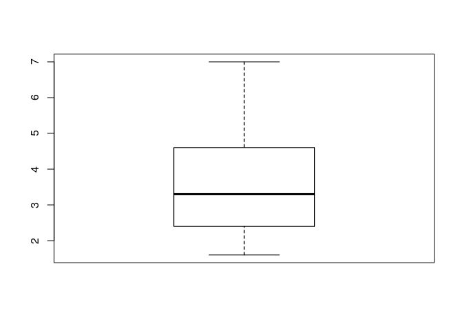

```r
boxplot(mpg$displ)
```

Boxplot shows the percentile of the given value.The top and bottom of the box are the 75th and 25th percentiles, respectively. The median is shown by the horizontal line in the box. The dashed lines, referred to aswhiskers, extend from the top and bottom to indicate the range for the bulk of the data.

#### Histogram

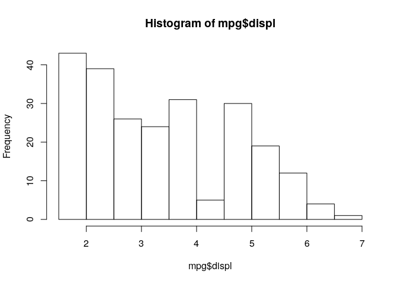

```r
hist(mpg$displ)
```

A histogram is a visualization, with bins on the x-axis and data count on the y-axis.

#### DensityPlot

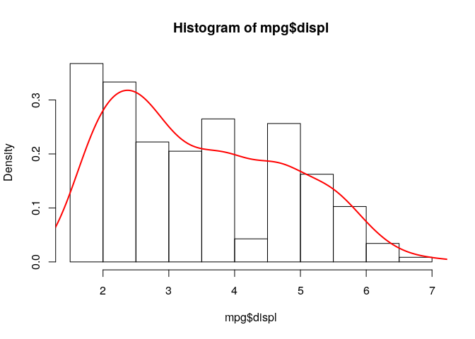

```r
hist(mpg$displ,freq = FALSE)
lines(density(mpg$displ),col="red",lwd=2)
```

#### Exploring Binary and Categorical Data

## Mode

```r
Mode <- function(x) {
which.max(table(x))
}

Mode(mpg$manufacturer)
```

```
## dodge
##     3
```

#### Bar Chart

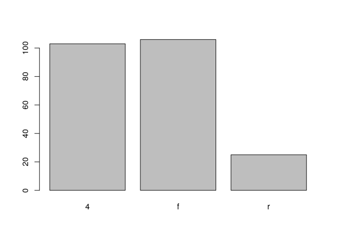

```r
barplot(table(mpg[["drv"]]))
```

## Correlation

```r
cor(mpg[c(3,5,8,9)])
```

```
##            displ        cyl        cty        hwy
## displ  1.0000000  0.9302271 -0.7985240 -0.7660200
## cyl    0.9302271  1.0000000 -0.8057714 -0.7619124
## cty   -0.7985240 -0.8057714  1.0000000  0.9559159
## hwy   -0.7660200 -0.7619124  0.9559159  1.0000000
```

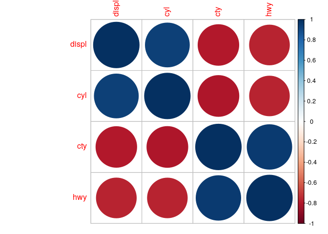

```r
library(corrplot)
corrplot(cor(mpg[c(3,5,8,9)]))
```

#### Scatterplot

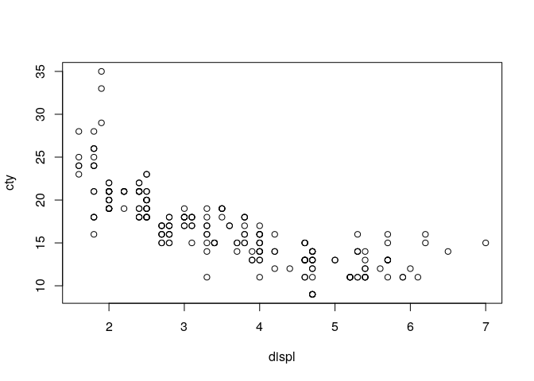

```r
plot(mpg$displ,mpg$cty,xlab= "displ", ylab="cty")
```

The standard way to visualize the relationship between two measured data variables is with a scatterplot.

## Exploring Two or More Variables(Multivariate)

#### Categorical and Numeric Data

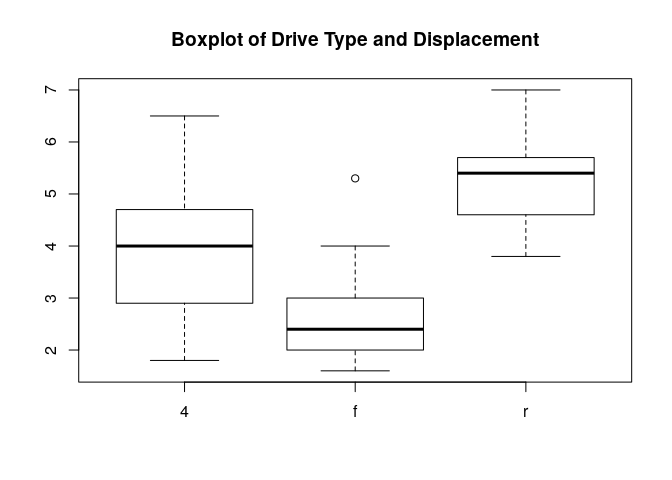

```r
boxplot(displ ~ drv, data = mpg)
title("Boxplot of Drive Type and Displacement")
```

#### Visualizing Multiple Variables

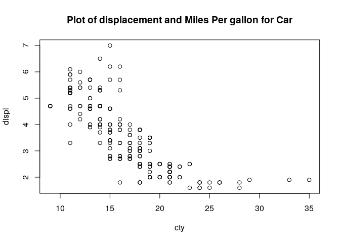

[figure not shown]

```r
plot(displ~cty,data =mpg)
title("Plot of displacement and Miles Per gallon for Car")
```

# Basic of Data Transformation and Visualization

## Prerequisites

In this Section we will learn how to do Data Transformation using dplyr package of tidyverse.

```r
library(dplyr)
```

#### Filter rows with filter()

filter() allows you to subset observations based on their values.

```r
tail(filter(mpg,drv=="f", year == 2008))
```

|  | manufacturer | model | displ | year | cyl | trans | drv | cty | hwy | fl | class |
| --- | --- | --- | --- | --- | --- | --- | --- | --- | --- | --- | --- |
| 44 | volkswagen | jetta | 2.5 | 2008 | 5 | manual(m5) | f | 21 | 29 | r | compact |
| 45 | volkswagen | new beetle | 2.5 | 2008 | 5 | manual(m5) | f | 20 | 28 | r | subcompact |
| 46 | volkswagen | new beetle | 2.5 | 2008 | 5 | auto(s6) | f | 20 | 29 | r | subcompact |
| 47 | volkswagen | passat | 2.0 | 2008 | 4 | auto(s6) | f | 19 | 28 | p | midsize |
| 48 | volkswagen | passat | 2.0 | 2008 | 4 | manual(m6) | f | 21 | 29 | p | midsize |
| 49 | volkswagen | passat | 3.6 | 2008 | 6 | auto(s6) | f | 17 | 26 | p | midsize |

#### Arrange rows with arrange()

```r
head(arrange(mpg,drv,displ))
```

| manufacturer | model | displ | year | cyl | trans | drv | cty | hwy | fl | class |
| --- | --- | --- | --- | --- | --- | --- | --- | --- | --- | --- |
| audi | a4 quattro | 1.8 | 1999 | 4 | manual(m5) | 4 | 18 | 26 | p | compact |
| audi | a4 quattro | 1.8 | 1999 | 4 | auto(l5) | 4 | 16 | 25 | p | compact |
| audi | a4 quattro | 2.0 | 2008 | 4 | manual(m6) | 4 | 20 | 28 | p | compact |
| audi | a4 quattro | 2.0 | 2008 | 4 | auto(s6) | 4 | 19 | 27 | p | compact |
| subaru | impreza awd | 2.2 | 1999 | 4 | auto(l4) | 4 | 21 | 26 | r | subcompact |
| subaru | impreza awd | 2.2 | 1999 | 4 | manual(m5) | 4 | 19 | 26 | r | subcompact |

#### Select columns with select()

select() allows to look in subset of data using columns name.

```r
head(select(mpg,class,trans,year,displ))
```

| class | trans | year | displ |
| --- | --- | --- | --- |
| compact | auto(l5) | 1999 | 1.8 |
| compact | manual(m5) | 1999 | 1.8 |
| compact | manual(m6) | 2008 | 2.0 |
| compact | auto(av) | 2008 | 2.0 |
| compact | auto(l5) | 1999 | 2.8 |
| compact | manual(m5) | 1999 | 2.8 |

If you use “-” before the name of column ,that column will be discarded.

#### Add new variables with mutate()

mutate() helps to add new column at the end of the dataframe using value of existing column.

```r
head(mutate(mpg,dmpg = hwy - cty))
```

| manufacturer | model | displ | year | cyl | trans | drv | cty | hwy | fl | class | dmpg |
| --- | --- | --- | --- | --- | --- | --- | --- | --- | --- | --- | --- |
| audi | a4 | 1.8 | 1999 | 4 | auto(l5) | f | 18 | 29 | p | compact | 11 |
| audi | a4 | 1.8 | 1999 | 4 | manual(m5) | f | 21 | 29 | p | compact | 8 |
| audi | a4 | 2.0 | 2008 | 4 | manual(m6) | f | 20 | 31 | p | compact | 11 |
| audi | a4 | 2.0 | 2008 | 4 | auto(av) | f | 21 | 30 | p | compact | 9 |
| audi | a4 | 2.8 | 1999 | 6 | auto(l5) | f | 16 | 26 | p | compact | 10 |
| audi | a4 | 2.8 | 1999 | 6 | manual(m5) | f | 18 | 26 | p | compact | 8 |

We calculated difference between city miles per gallon and highway miles per gallon.

[figure not shown]

#### Grouped summaries with summarise()

summarise() collapses the dataframe to a single Rows.

```r
summarise(mpg,avg_hwy=mean(hwy))
```

| avg_hwy |
| --- |
| 23.44017 |

When summarise() is used with group_by(), the unit of analysis is changed from the complete dataset to individual groups.

```r
grouped_mpg<- group_by(mpg,year,cyl)
summarise(grouped_mpg,avg_hwy = mean(hwy))
```

```
## # A tibble: 7 x 3
## # Groups:   year [?]
##    year   cyl avg_hwy
##   <int> <int>   <dbl>
## 1  1999     4    28.4
## 2  1999     6    22.3
## 3  1999     8    17.0
## 4  2008     4    29.3
## 5  2008     5    28.8
## 6  2008     6    23.5
## 7  2008     8    18.0
```

## Data visualisation

> “The simple graph has brought more information to the data analyst’s mind than any other device.” — John Tukey

#### Prerequisites

In this section we will use ggplot2, one of the core members of the tidyverse.

#### ScatterPlot

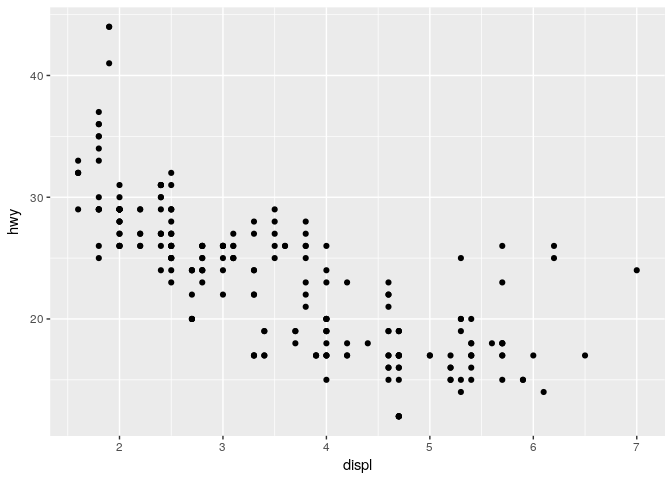

```r
ggplot(data = mpg) +
  geom_point(mapping = aes(x = displ, y = hwy))
```

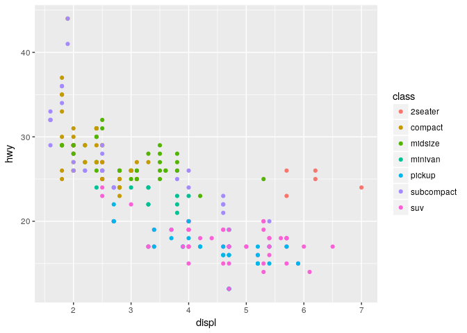

```r
ggplot(data = mpg) +
  geom_point(mapping = aes(x = displ, y = hwy, color = class))
```

#### Barplot

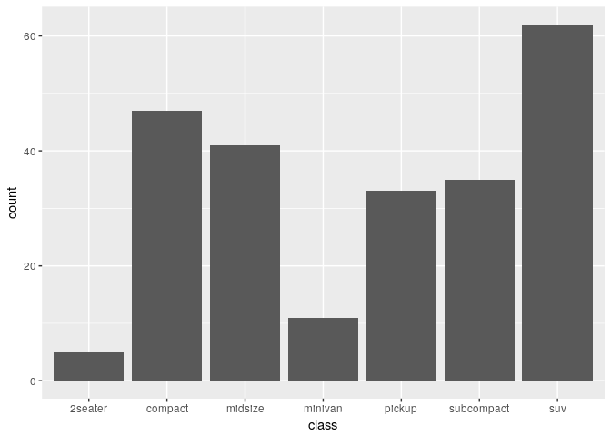

```r
ggplot(data = mpg) + geom_bar(aes(x=class))
```

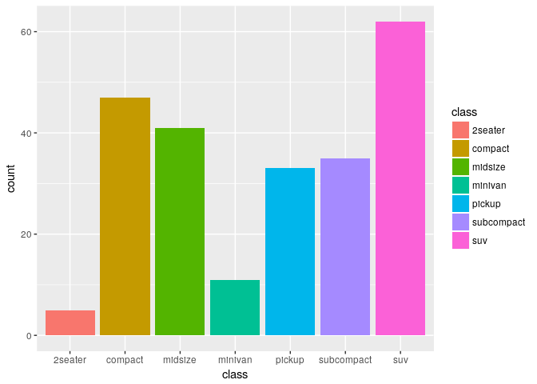

```r
ggplot(data = mpg) + geom_bar(aes(x=class, fill = class))
```

#### DensityPlot and Histogram

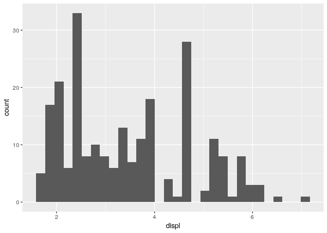

```r
ggplot(data = mpg) + geom_histogram(aes(x= displ))
```

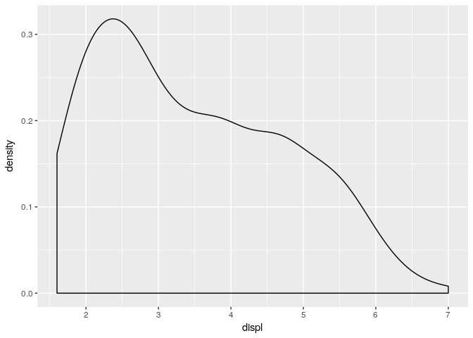

```r
ggplot(data = mpg) + geom_density(aes(x=displ))
```

#### Boxplot

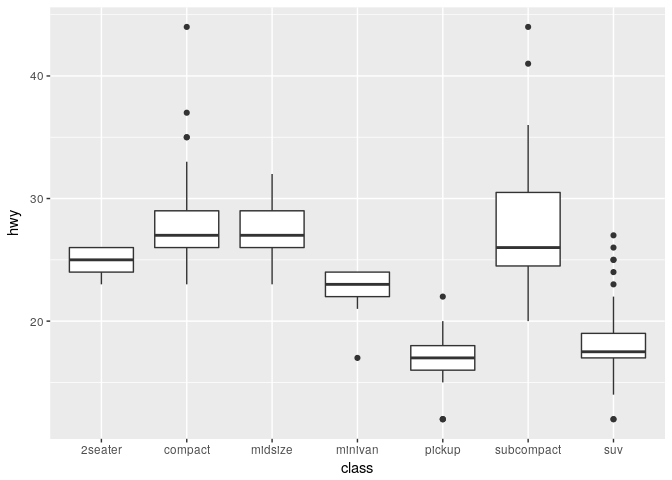

```r
ggplot(data = mpg, mapping = aes(x = class, y = hwy)) +
  geom_boxplot()
```

#### Facets

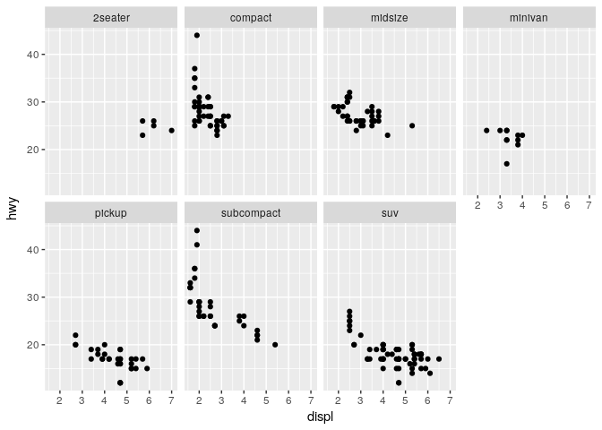

```r
ggplot(data = mpg) +
  geom_point(mapping = aes(x = displ, y = hwy)) +
  facet_wrap(~ class, nrow = 2)
```